# Formalização do Modelo v2

Manoel Galdino

2026-04-22

# 1 Environment

Let
$$V_e(\mu) \equiv 1 + \mu(r-1)$$
denote the expected value of cooperation at posterior belief $\mu$.

# 2 Institutional Packages

# 3 Timing

The game has three stages.

# 4 Solution Concept

The solution concept is Perfect Bayesian Equilibrium (PBE). Strategies are sequentially rational given beliefs, and beliefs are updated by Bayes’ rule on the equilibrium path. Off-path beliefs satisfy sequential rationality.

# 5 Game Tree

The game tree is presented for the unanimity subgame (Package $U$). Under Package $M$ (majority), the structure is identical except that $W$ proposers exclude $H$ from the coalition, eliminating the screening problem.

# 6 Equilibrium Analysis (to be developed)

## 6.1 Terminal Round (R2) under Unanimity

(prob $1/N$): offers $0$ to each $W$ ($d_W = 0$), all $W$’s accept (indifferent: $0 \geq 0$). $H$ keeps $V(\theta)$. This is the same for both types and does not involve screening. When $W$ decides to accept or reject, $W$ also doesn’t know $\theta$, but since the offer is $0$ and $d_W = 0$, $W$ is indifferent and accepts by convention.

(prob $1/N$): offers $0$ to other $W$’s (who accept by the same indifference argument). $W_j$ must decide what to offer $H$. This is the screening subgame, which we now analyze via the normal form.

### 6.1.1 R2 Screening Subgame: Normal Form

: $W$ (proposer, uninformed) and $H$ (responder, type $\theta \in \{0,1\}$).

. $W$ chooses an offer $y_H$. By dominance, only two offers are relevant:

Any $y_H < \alpha$ is rejected by both types; any $y_H \in (\alpha, \alpha r)$ is accepted by $\theta=0$ and rejected by $\theta=1$ (same as $A$ but costlier); any $y_H > \alpha r$ is accepted by both (same as $C$ but costlier).

$H$ of type $\theta$ chooses accept/reject for each possible offer. Writing $H$’s strategy as $(a_\theta^A, a_\theta^C) \in \{a, r\}^2$:

: After elimination, the remaining choices are:

$H$’s reduced strategy set: $(a_0^A, a_1^C) \in \{a,r\}^2$, giving 4 strategies. $W$’s strategy set: $\{A, C\}$.

: $H$ is indifferent at the non-dominated margins:

Therefore $H$’s payoff does not depend on $H$’s own strategy:
$$\begin{align}
u_H(\theta=0) &= \alpha \text{ if } W \text{ plays } A, \quad \alpha r \text{ if } W \text{ plays } C \\
u_H(\theta=1) &= \alpha r \text{ regardless of } W\text{'s action}
\end{align}$$

(expected over $\theta$ given beliefs $\mu = \Pr(\theta=1)$):

Columns are $H$’s strategies $(a_0^A, a_1^C)$. Note: $H$’s payoff is the same across all columns (indifferent).

. Since $H$ is indifferent, any strategy is a best response for $H$. The equilibrium is determined by $W$’s best response:

Multiple BNE exist (because $H$ is indifferent). The standard convention in bargaining games is: . This selects $(a,a)$: type $\theta=0$ accepts $A$, type $\theta=1$ accepts $C$.

Under $(a,a)$, $W$’s screening cutoff is:
$$\begin{equation}\label{eq:cutoff}
(1-\mu)(1-\alpha) = V_e(\mu) - \alpha r \quad \Longrightarrow \quad \mu_s = \frac{\alpha(r-1)}{r - \alpha}
\end{equation}$$

$W$ plays $A$ if $\mu < \mu_s$, $C$ if $\mu > \mu_s$.

### 6.1.2 R2 Continuation Values (combining H-proposes and W-proposes)

Averaging over proposer identity (prob $1/N$ each):

$V_W^{R2}(\mu)$:
$$\begin{align}
\mu < \mu_s: &\quad \frac{(1-\mu)(1-\alpha)}{N} \\
\mu > \mu_s: &\quad \frac{V_e(\mu) - \alpha r}{N}
\end{align}$$

: at $\mu_s = \alpha(r-1)/(r-\alpha)$, we have $1 - \mu_s = r(1-\alpha)/(r-\alpha)$, so $(1-\mu_s)(1-\alpha) = r(1-\alpha)^2/(r-\alpha)$. And $V_e(\mu_s) - \alpha r = 1 + \mu_s(r-1) - \alpha r = 1 + \alpha(r-1)^2/(r-\alpha) - \alpha r$. Simplifying: $= [r - \alpha + \alpha(r-1)^2 - \alpha r(r-\alpha)]/(r-\alpha) = [r - \alpha + \alpha r^2 - 2\alpha r + \alpha - \alpha r^2 + \alpha^2 r]/(r-\alpha) = [r - 2\alpha r + \alpha^2 r]/(r-\alpha) = r(1-\alpha)^2/(r-\alpha)$. Equal. $\checkmark$

$V_H^{R2}(\theta, \mu)$:
$$\begin{align}
\theta = 1: &\quad \frac{r[1+(N-1)\alpha]}{N} \quad \text{(constant in $\mu$)} \\
\theta = 0, \; \mu < \mu_s: &\quad \frac{1 + (N-1)\alpha}{N} \\
\theta = 0, \; \mu > \mu_s: &\quad \frac{1 + (N-1)\alpha r}{N} \quad \text{(overpaid)}
\end{align}$$

$$\begin{equation}\label{eq:jump}
\text{Jump} = \frac{(N-1)\alpha(r-1)(1-\mu_s)}{N} > 0
\end{equation}$$

### 6.1.3 Source of the difference between unanimity and majority

### 6.1.4 Numerical Examples (R2 under Unanimity, $N=5$, $\mu = 0.5$)

: $r = 1.1$, $\alpha = 0.5$ (bilateral captures 50% of multilateral value; $\alpha < 1/r = 0.909$ $\checkmark$).

Screening cutoff: $\mu_s = 0.5 \times 0.1 / (1.1 - 0.5) = 0.05/0.6 \approx 0.083$.

Since $\mu = 0.5 > \mu_s$, $W$ plays (offers $y_H = \alpha r = 0.55$).

(expected over $\theta$, given $\mu = 0.5$):

Under $(a,a)$: $W$ prefers $C$ ($0.50 > 0.25$). $\checkmark$ Consistent with $\mu > \mu_s$.

:

The expected pie is $V_e(0.5) = 1.05$.

$H$ expects to receive: $0.65$ (62% of expected pie). Each $W$ expects to receive: $0.10$ (9.5% of expected pie).

Budget check: $H(0.65) + 4 \times W(0.10) = 0.65 + 0.40 = 1.05 = V_e(0.5)$. $\checkmark$

Jump magnitude at $\mu_s$: $4 \times 0.5 \times 0.1 \times (1 - 0.083)/5 = 0.037$.

Interpretation: $r$ close to 1 means the states are similar, $\alpha$ high means $H$ has strong bilateral alternatives. The screening cutoff $\mu_s$ is very low (8.3%): $W$ almost always plays conservative. The jump is small.

: $r = 1.5$, $\alpha = 0.3$ (bilateral captures 30%; $\alpha < 1/r = 0.667$ $\checkmark$).

Screening cutoff: $\mu_s = 0.3 \times 0.5 / (1.5 - 0.3) = 0.15/1.2 = 0.125$.

Since $\mu = 0.5 > \mu_s$, $W$ plays (offers $y_H = \alpha r = 0.45$).

(expected over $\theta$, given $\mu = 0.5$):

Under $(a,a)$: $W$ prefers $C$ ($0.80 > 0.35$). $\checkmark$

:

The expected pie is $V_e(0.5) = 1.25$.

$H$ expects to receive: $0.61$ (49% of expected pie). Each $W$ expects to receive: $0.16$ (12.8% of expected pie).

Budget check: $H(0.61) + 4 \times W(0.16) = 0.61 + 0.64 = 1.25 = V_e(0.5)$. $\checkmark$

Jump magnitude at $\mu_s$: $4 \times 0.3 \times 0.5 \times (1 - 0.125)/5 = 0.105$.

: In Example 1 ($\alpha$ high, $r$ low), $H$ captures 62% of the expected pie — strong bilateral alternatives give bargaining power. In Example 2 ($\alpha$ low, $r$ high), $H$ captures 49% — weaker outside option. But the jump is larger in Example 2 ($0.105$ vs $0.037$): the screening channel is most powerful precisely when $H$ is ``weaker’’ in terms of outside option.

($r=1.1$, $\alpha=0.5$, $\mu=0.5$, $\mu_s \approx 0.083$):

($r=1.5$, $\alpha=0.3$, $\mu=0.5$, $\mu_s = 0.125$):

## 6.2 Terminal Round (R2) under Majority

(prob $1/N$): buys $q-1$ votes (offers $0$, $d_W = 0$). Keeps $V(\theta)$.

(prob $(N-1)/N$): $W$ is indifferent between excluding $H$ (coalition gets $(1-\alpha)V(\theta)$, $H$ captures $\alpha V(\theta)$ bilaterally) and including $H$ at reservation $\alpha V(\theta)$ ($W$ keeps $(1-\alpha)V(\theta)$, $H$ gets $\alpha V(\theta)$ from the deal). Payoffs are identical. : $W$ includes $H$ in the proposal (WLOG). This ensures the full pie $V(\theta)$ is divided among all $N$ players under both voting rules, simplifying comparison. $W$ offers $\alpha V(\theta)$ to $H$, offers $0$ to $q-2$ other $W$’s in the coalition, and keeps $(1-\alpha)V(\theta)$.

Note: under majority, the proposal passes regardless of $H$’s vote ($W$ has $q-1$ other votes). $H$ accepts the offer $\alpha V(\theta)$ (weakly: it equals $H$’s outside option). There is no screening because $H$’s acceptance has no consequence for whether the deal passes — unlike unanimity, where $H$’s rejection kills the proposal.

$$\begin{align}
V_H^{R2}(\theta, M) &= \frac{V(\theta)[1 + (N-1)\alpha]}{N} \quad \text{--- linear in $\mu$, no screening.} \\
V_W^{R2}(\mu, M) &= \frac{(1-\alpha)V_e(\mu)}{N}
\end{align}$$

: $H$ proposes with prob $1/N$ and keeps $V(\theta)$. $W$ proposes with prob $(N-1)/N$ and offers $H$ exactly $\alpha V(\theta)$. So $V_H = (1/N)V(\theta) + ((N-1)/N)\alpha V(\theta) = V(\theta)[1+(N-1)\alpha]/N$. Taking expectations: $E_\theta[V_H^{R2}(\mu, M)] = V_e(\mu)[1+(N-1)\alpha]/N$, affine in $\mu$. $\checkmark$

: $W_i$ proposes with prob $1/N$ and keeps $(1-\alpha)V(\theta)$ (offers $\alpha V(\theta)$ to $H$, $0$ to other $W$’s). When $H$ proposes (prob $1/N$), $W_i$ receives $0$. When another $W_j$ proposes (prob $(N-2)/N$), $W_i$ receives $0$. So $V_W = (1/N)(1-\alpha)E[V(\theta)] = (1-\alpha)V_e(\mu)/N$. $\checkmark$

: $E[V_H] + (N-1)V_W = V_e(\mu)[1+(N-1)\alpha]/N + (N-1)(1-\alpha)V_e(\mu)/N = V_e(\mu) \cdot N/N = V_e(\mu)$. $\checkmark$

### 6.2.1 Numerical Examples and Comparison (R2, Majority vs Unanimity, $\mu = 0.5$)

Under majority there is no screening: $W$ excludes $H$, so $H$ always receives $\alpha V(\theta)$ when $W$ proposes (type-specific, no overpayment).

($r=1.1$, $\alpha=0.5$, $\mu=0.5$):

:

:

($r=1.5$, $\alpha=0.3$, $\mu=0.5$):

:

:

### 6.2.2 H’s gain from unanimity over majority

The gain $\Delta(\mu) = E_\theta[V_H^{R2}(U,\mu)] - E_\theta[V_H^{R2}(M,\mu)]$ has a simple closed form:
$$\Delta(\mu) = \begin{cases} 0 & \mu \leq \mu_s \\ \displaystyle\frac{(1-\mu)(N-1)\alpha(r-1)}{N} & \mu > \mu_s \end{cases}$$

(for $\mu > \mu_s$):

: $\partial \Delta / \partial \alpha > 0$ at a given $\mu$ does not mean the gain is increasing in $\alpha$. Higher $\alpha$ raises $\mu_s$ (shrinking the conservative region where the gain exists). The maximum gain $\Delta(\mu_s)$ depends on $\alpha$ through both the numerator and $(1-\mu_s)$.

($r=1.1$, $\alpha=0.5$, $N=5$, $\mu_s \approx 0.083$):

($r=1.5$, $\alpha=0.3$, $N=5$, $\mu_s = 0.125$):

The gain is modest in absolute terms but persistent: it does not vanish with $N$ and is largest at low $\mu$ (just above $\mu_s$), which is precisely the region where BP operates.

Key observations from the comparison:

## 6.3 Round 1 (R1) under Unanimity

Let $x \equiv (N-1)\alpha r$ throughout this section.

### 6.3.1 When $H$ proposes in R1 (prob $1/N$)

$H$ offers $\beta V_W^{R2}(\mu)$ to each $W$ (their discounted R2 continuation value). Both types of $H$ make the same offer (pooling: the offer depends on $\mu$, not on $\theta$, since $V_W^{R2}$ is a function of $\mu$ only). All $W$’s accept (indifferent). $H$ keeps $V(\theta) - (N-1)\beta V_W^{R2}(\mu)$.

No information about $\theta$ is revealed by $H$’s proposal (same offer for both types).

### 6.3.2 When $W$ proposes in R1 (prob $(N-1)/N$)

$W$ offers 0 to other $W$’s (their reservation from R2 is $\beta V_W^{R2}(\mu) > 0$… but other $W$’s accept 0 only if 0 $\geq$ their continuation from rejection).

: $W_j$ must offer each $W_k$ at least $\beta V_W^{R2}(\mu')$ where $\mu'$ depends on rejection beliefs. On the equilibrium path where the proposal is accepted, the exact value matters only for budget accounting. We set $x_k = \beta V_W^{R2}(\mu)$ for each $W_k$ (using on-path beliefs). All $W_k$ accept.

$W_j$ must decide what to offer $H$. The two relevant offers are:

: $y_H^{con} = \beta(r + x)/N$

This is $\beta \times V_H^{R2}(\theta=1)$, the discounted R2 continuation of the more demanding type. Both types accept:

Game ends in R1.

: $y_H^{agg} = \beta(1 + x)/N$

This is $\beta \times V_H^{R2}(\theta=0, \mu'=1)$, the discounted R2 continuation of type $\theta=0$ under the belief $\mu'=1$ (which is what $W$ would believe after rejection, since only $\theta=1$ rejects on path).

: $\beta(r+x)/N - \beta(1+x)/N = \beta(r-1)/N > 0$. Screening is feasible.

### 6.3.3 R2 after R1 rejection (complete information)

When $\theta=1$ rejects the aggressive offer in R1, the game goes to R2 with $W$ knowing $\theta=1$:

R2 payoffs (under complete information, $\theta=1$):
$$\begin{align}
V_H^{R2}(\theta=1, \text{known}) &= \frac{r + x}{N} \\
V_W^{R2}(\theta=1, \text{known}) &= \frac{r(1-\alpha)}{N}
\end{align}$$

### 6.3.4 $W$’s expected payoff from each strategy in R1

Let $\omega(\mu) \equiv (N-2)\beta V_W^{R2}(\mu)$ denote the total payment to other $W$’s in R1.

(both types accept, game ends in R1):
$$\begin{align}
F_1^{con}(\mu) &= E[V(\theta)] - \frac{\beta(r+x)}{N} - \omega(\mu) \nonumber \\
&= V_e(\mu) - \frac{\beta(r+x)}{N} - \omega(\mu) \label{eq:F1con}
\end{align}$$

($\theta=0$ accepts in R1; $\theta=1$ rejects, goes to R2):
$$\begin{align}
F_1^{agg}(\mu) &= (1-\mu)\left[V(0) - \frac{\beta(1+x)}{N} - \omega(\mu)\right] + \mu \cdot \frac{\beta r(1-\alpha)}{N} \label{eq:F1agg}
\end{align}$$

The first term: with prob $(1-\mu)$, $\theta=0$ accepts. $W$ keeps $V(0) - y_H^{agg} - \omega(\mu) = 1 - \beta(1+x)/N - \omega(\mu)$.

The second term: with prob $\mu$, $\theta=1$ rejects. Game goes to R2 with complete information. $W$’s expected R2 payoff (discounted): $\beta V_W^{R2}(\theta=1, \text{known}) = \beta r(1-\alpha)/N$.

### 6.3.5 R1 screening cutoff

$W$ prefers aggressive when $F_1^{agg}(\mu) > F_1^{con}(\mu)$:
$$\begin{align}
&(1-\mu)\left[1 - \frac{\beta(1+x)}{N} - \omega\right] + \frac{\mu \beta r(1-\alpha)}{N} > V_e(\mu) - \frac{\beta(r+x)}{N} - \omega \nonumber
\end{align}$$

Expanding and simplifying (the $\omega(\mu)$ terms partially cancel):

Left side:
$$(1-\mu) - \frac{(1-\mu)\beta(1+x)}{N} - (1-\mu)\omega + \frac{\mu\beta r(1-\alpha)}{N}$$

Right side:
$$V_e(\mu) - \frac{\beta(r+x)}{N} - \omega$$

Difference (Left $-$ Right):
$$\begin{align}
&(1-\mu) - V_e(\mu) - \frac{(1-\mu)\beta(1+x)}{N} + \frac{\beta(r+x)}{N} + \frac{\mu\beta r(1-\alpha)}{N} + \mu\omega \nonumber
\end{align}$$

Note: $V_e(\mu) = 1 + \mu(r-1)$, so $(1-\mu) - V_e(\mu) = -\mu r$.

$$\begin{align}
&= -\mu r + \frac{\beta}{N}\left[-(1-\mu)(1+x) + (r+x) + \mu r(1-\alpha)\right] + \mu\omega \nonumber
\end{align}$$

The bracket:
$$\begin{align}
&-(1+x) + \mu(1+x) + r + x + \mu r(1-\alpha) \nonumber \\
&= r - 1 + \mu(1 + x + r - r\alpha) \nonumber \\
&= (r-1) + \mu(1 + r + x - r\alpha) \nonumber
\end{align}$$

Since $x = (N-1)\alpha r$, we have $x - r\alpha = (N-2)\alpha r$. So:
$$= (r-1) + \mu(1 + r + (N-2)\alpha r)$$

The full difference:
$$\Delta_1(\mu) = -\mu r + \frac{\beta}{N}\left[(r-1) + \mu(1 + r + (N-2)\alpha r)\right] + \mu\omega(\mu)$$

This depends on $\omega(\mu) = (N-2)\beta V_W^{R2}(\mu)$, which is piecewise (depends on which branch of $V_W^{R2}$ applies). The cutoff $\mu_s^{R1}$ solves $\Delta_1(\mu) = 0$.

Rather than solving in full generality (the algebra is involved because $V_W^{R2}$ is piecewise), we proceed numerically for the examples and note the closed-form structure.

### 6.3.6 Continuation values in R1 under unanimity

Averaging over proposer identity:

$V_H^{R1}(\theta, \mu)$:
$$\begin{align}
&= \frac{1}{N}\left[V(\theta) - (N-1)\beta V_W^{R2}(\mu)\right] \quad \text{(H proposes)} \nonumber \\
&+ \frac{N-1}{N} \times \begin{cases}
\frac{\beta(1+x)}{N} & \text{if } \mu < \mu_s^{R1}, \; \theta=0 \text{ (aggressive, accepts)} \\
\frac{\beta(r+x)}{N} & \text{if } \mu > \mu_s^{R1} \text{ (conservative, both accept)} \\
\beta V_H^{R2}(\theta=1, \text{known}) = \frac{\beta(r+x)}{N} & \text{if } \mu < \mu_s^{R1}, \; \theta=1 \text{ (aggressive, rejects $\to$ R2)}
\end{cases}
\end{align}$$

Simplifying for each type:

:
$$\begin{align}
V_H^{R1}(\theta=1, \mu) &= \frac{1}{N}\left[r - (N-1)\beta V_W^{R2}(\mu)\right] + \frac{(N-1)\beta(r+x)}{N^2}
\end{align}$$
This does not depend on whether $W$ plays aggressive or conservative (type $\theta=1$ gets $\beta(r+x)/N$ either way — accepts conservative, rejects aggressive and gets R2 payoff $(r+x)/N$). Constant across screening branches.

:
$$\begin{align}
V_H^{R1}(\theta=0, \mu < \mu_s^{R1}) &= \frac{1}{N}\left[1 - (N-1)\beta V_W^{R2}(\mu)\right] + \frac{(N-1)\beta(1+x)}{N^2}
\end{align}$$

:
$$\begin{align}
V_H^{R1}(\theta=0, \mu > \mu_s^{R1}) &= \frac{1}{N}\left[1 - (N-1)\beta V_W^{R2}(\mu)\right] + \frac{(N-1)\beta(r+x)}{N^2}
\end{align}$$

:
$$\text{Jump}_{\theta=0} = \frac{(N-1)\beta(r-1)}{N^2}$$
This comes from $\theta=0$ receiving $\beta(r+x)/N$ (conservative) vs $\beta(1+x)/N$ (aggressive) when $W$ proposes, weighted by prob $(N-1)/N$ of $W$ proposing.

:
$$\text{Jump} = (1-\mu_s^{R1}) \times \frac{(N-1)\beta(r-1)}{N^2}$$
(Only $\theta=0$ is affected; $\theta=1$’s payoff is the same on both sides.)

### 6.3.7 Numerical examples (R1 under Unanimity)

: $r=1.1$, $\alpha=0.5$, $N=5$, $\beta=0.9$

$\mu_s^{R2} = 0.083$, $x = (N-1)\alpha r = 2.2$

: $r=1.5$, $\alpha=0.3$, $N=5$, $\beta=0.9$

$\mu_s^{R2} = 0.125$, $x = (N-1)\alpha r = 1.8$

## 6.4 Round 1 (R1) under Majority

Under majority, $W$ includes $H$ at reservation $\alpha V(\theta)$ (WLOG convention). The proposal passes regardless of $H$’s vote. No screening.

: $H$ offers $\beta V_W^{R2}(\mu, M) = \beta(1-\alpha)V_e(\mu)/N$ to each $W$ in the coalition. $W$ accepts. $H$ keeps $V(\theta) - (q-1)\beta(1-\alpha)V_e(\mu)/N$.

: $W$ offers $\alpha V(\theta)$ to $H$ (reservation, type-specific). But $W$ doesn’t know $\theta$. Under majority, this doesn’t matter: the proposal passes regardless. $W$ offers $\beta\alpha V_e(\mu)$ (expected reservation) to $H$ and keeps the rest. Actually, since the proposal passes by majority without $H$’s vote, $W$ can offer any amount. By the WLOG convention (include $H$), $W$ offers $\alpha V(\theta)$. Since $W$ doesn’t know $V(\theta)$, $W$ offers $\beta \cdot \alpha V_e(\mu)$ and $H$ gets $\alpha V(\theta)$ regardless (either from the deal or outside option).

In practice, the R1 payoffs under majority are just discounted R2 values:
$$\begin{align}
V_H^{R1}(\theta, M) &= \frac{V(\theta)[1 + (N-1)\alpha \cdot \phi(\beta)]}{N} \\
V_W^{R1}(\mu, M) &= \frac{(1-\alpha)V_e(\mu) \cdot \psi(\beta)}{N}
\end{align}$$
where $\phi$ and $\psi$ are functions of $\beta$ from the standard BF backward induction. The key point: everything remains .

A full derivation of R1 under majority parallels the unanimity case but without the aggressive/conservative distinction. Since there is no screening, the continuation values are affine in $\mu$ and do not contribute to BP. We defer the exact expressions to focus on the unanimity mechanism.

## 6.5 Entry

A weak state enters if its expected payoff from participating exceeds the entry cost:
$$V_W^{R1}(\mu, R) \geq c$$

The entry threshold $\tau(R)$ is the value of $\mu$ at which $W$ is indifferent.

### 6.5.1 Entry under unanimity

$V_W^{R1}(\mu, U)$ is piecewise: it depends on whether $W$ plays aggressive or conservative in R1 (cutoff $\mu_s^{R1}$), and within the aggressive branch, on $V_W^{R2}(\mu)$ (cutoff $\mu_s$). So $V_W^{R1}$ can have up to three regimes.

The entry threshold $\tau(U)$ solves $V_W^{R1}(\tau, U) = c$. Since $V_W^{R1}$ is not monotone in general (it depends on the piecewise structure), the threshold may not be unique. We characterize it numerically for the examples.

With $c = 0.1$, $\beta = 0.9$:

### 6.5.2 Entry under majority

Under majority, $V_W^{R1}(\mu, M)$ is affine in $\mu$ (no screening, no piecewise structure). The entry threshold $\tau(M)$ solves $V_W^{R1}(\tau, M) = c$, which has a unique solution.

### 6.5.3 Entry comparison

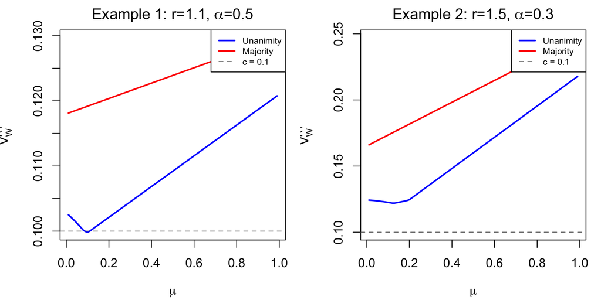

(#fig:entry_plot)$V_W^{R1}(\mu)$ under unanimity and majority for both examples. Horizontal line: entry cost $c = 0.1$. Entry occurs where the curve exceeds $c$.

## 6.6 Bayesian Persuasion

$H$ chooses the institutional rule $R$ at Stage 0 and the signal structure $\pi$ at Stage 1 to maximize expected payoff. By the standard Bayesian Persuasion result (Kamenica and Gentzkow 2011), $H$’s optimal payoff under rule $R$ equals the concavification of $H$’s value function evaluated at the prior $p$:
$$\Pi_H^*(R) = \operatorname{cav} v(p, R)$$

### 6.6.1 $H$’s value function

$H$’s value function maps posteriors $\mu$ to $H$’s expected payoff:
$$v(\mu, R) = \begin{cases}
0 & \text{if } V_W^{R1}(\mu, R) < c \quad \text{(no entry)} \\
E_\theta[V_H^{R1}(\theta, \mu, R)] & \text{if } V_W^{R1}(\mu, R) \geq c \quad \text{(entry)}
\end{cases}$$

When $W$ does not enter, $H$ gets 0 (no institution). When $W$ enters, $H$ gets the expected R1 payoff.

: $v(\mu, M) = \mathbf{1}\{V_W^{R1}(\mu, M) \geq c\} \cdot E_\theta[V_H^{R1}(\theta, \mu, M)]$. Both the indicator and the continuation value are affine (or piecewise affine) in $\mu$. The value function has a jump at $\tau(M)$ (entry threshold) but is linear above it. BP exploits only the entry threshold.

: $v(\mu, U)$ has TWO sources of non-convexity:

BP can exploit both non-convexities. This is the screening channel that is absent under majority.

### 6.6.2 Analytical concavification

. The value function under unanimity is:
$$v(\mu, U) = \begin{cases}
0 & \mu < \tau(U) \\
v_L(\mu) & \tau(U) \leq \mu < \mu_s^{R1} \\
v_H(\mu) & \mu \geq \mu_s^{R1}
\end{cases}$$
where $v_L(\mu) = E_\theta[V_H^{R1}(\theta, \mu)]$ on the aggressive branch (pre-screening) and $v_H(\mu) = E_\theta[V_H^{R1}(\theta, \mu)]$ on the conservative branch (post-screening). There is an upward jump at $\mu_s^{R1}$:
$$v_H(\mu_s^{R1}) - v_L(\mu_s^{R1}) = (1 - \mu_s^{R1}) \cdot \frac{(N-1)\beta(r-1)}{N^2} > 0.$$

Both $v_L$ and $v_H$ depend on $V_W^{R2}(\mu)$ and are continuous on their respective domains.

. Under majority:
$$v(\mu, M) = \begin{cases}
0 & \mu < \tau(M) \\
E_\theta[V_H^{R1}(\theta, \mu, M)] & \mu \geq \tau(M)
\end{cases}$$
This is affine in $\mu$ for $\mu \geq \tau(M)$. No jump, no non-convexity beyond the entry threshold.

The concavification from the origin creates a line with slope:
$$S(R) = \sup_{\mu \in [\tau(R), 1]} \frac{v(\mu, R)}{\mu}$$
and $\operatorname{cav} v(p, R) = S(R) \cdot p$ for $p < \tau(R)$.

Under majority: $v(\mu, M) = A_M + B_M \mu$ is affine for $\mu \geq \tau(M)$, so $v/\mu$ is decreasing. The supremum is at $\mu = \tau(M)$:
$$S_M = \frac{v(\tau(M), M)}{\tau(M)}$$

Under unanimity: $v/\mu$ can attain a higher value at the jump. If $v_H(\mu_s^{R1})/\mu_s^{R1} > v_L(\mu)/\mu$ for all $\mu \in [\tau(U), \mu_s^{R1})$, the supremum is at $\mu_s^{R1}$ (from the right):
$$S_U = \frac{v_H(\mu_s^{R1})}{\mu_s^{R1}}$$

In this case, $v(p, U) > 0$. The BP gain comes from exploiting the screening jump at $\mu_s^{R1}$. The concavification bridges the non-convexity: for priors near $\mu_s^{R1}$, $H$ creates posteriors straddling the jump.

Formally, there exist $\mu_1 < \mu_s^{R1} < \mu_2$ such that the line connecting $({\mu_1, v_L(\mu_1)})$ to $({\mu_2, v_H(\mu_2)})$ is tangent to $v_L$ at $\mu_1$ and tangent to $v_H$ at $\mu_2$. For $p \in (\mu_1, \mu_2)$:
$$\operatorname{cav} v(p, U) = v_L(\mu_1) + \frac{v_H(\mu_2) - v_L(\mu_1)}{\mu_2 - \mu_1}(p - \mu_1) > v(p, U).$$

The optimal signal creates two posteriors: $\mu_1$ (with prob $(\mu_2 - p)/(\mu_2 - \mu_1)$) and $\mu_2$ (with prob $(p - \mu_1)/(\mu_2 - \mu_1)$). At $\mu_1$, $W$ plays aggressive. At $\mu_2$, $W$ plays conservative. $H$ benefits from the switch.

Under majority, $v(\mu, M)$ is concave for $\mu \geq \tau(M)$, so $\operatorname{cav} v(p, M) = v(p, M)$. No BP gain beyond entry.

:

### 6.6.3 Numerical illustration

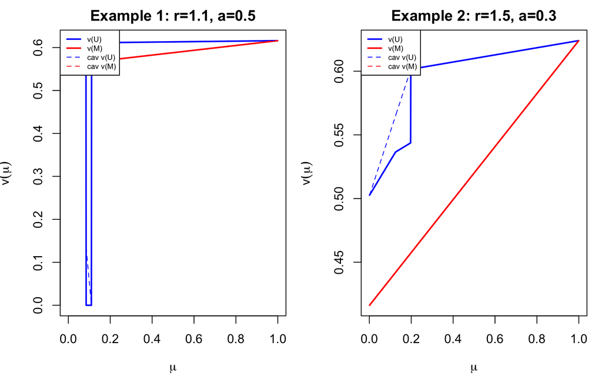

(#fig:bp_plot)$H$’s value function $v(\mu, R)$ and its concavification under both rules. Dashed: concave envelope. The screening jump under unanimity creates additional concavification gain.

: The concavification under unanimity exploits both the entry threshold and the screening jump. Under majority, only the entry threshold is available. For priors $p$ where $\operatorname{cav} v(p, U) > \operatorname{cav} v(p, M)$, $H$ prefers unanimity.

### 6.6.4 $H$’s optimal payoff comparison

## 6.7 Institutional Comparison without BP

Before deriving the full theorem with BP, we characterize the comparison Bayesian Persuasion (i.e., $W$ uses the prior $p$ directly, no signal).

## 6.8 Institutional Comparison with BP — to derive (Theorem)

# 7 Open Questions